# TIMES HCC case study - personalised posteriorHCA baseline

Patient-specific healthy liver NK predictive and heteroscedastic log-mean tests

Abstract

This companion analysis replaces the comprehensive cohort-level baseline with a personalised healthy liver NK baseline for each HCC patient-compartment pseudobulk. Known age decade, sex, liver tissue, and the aligned TMMwsp offset are retained. Unknown ethnicity and the unseen GeoMx assay level are marginalised using their empirical joint distribution among healthy liver NK atlas samples. A new GeoMx dataset effect is drawn from the fitted hierarchical distribution. Because each comparison is one observed count against a posterior distribution, the primary test uses `posterior_predict()`. A secondary `posterior_linpred()` analysis estimates a patient log mean and NB sampling SE, then applies a heteroscedastic normal (Welch-style) test against the matched healthy posterior mean and SD. `posterior_epred()` summarises the personalised healthy expected count and effect size.

# Analysis question

The comprehensive-baseline report estimates one healthy grand mean per gene and one mean per HCC cohort. This report instead asks a patient-level question:

> Is one observed HCC patient-compartment gene count surprising under the posterior predictive distribution of a metadata-matched healthy liver NK sample at the same library-size offset?

The healthy counterfactual keeps only information known for that patient and represented by the atlas model:

| Model term | Personalised treatment |
| --- | --- |
| `age_decade` | Patient age converted with `ceiling(age / 10)` |
| `sex` | Patient sex, lower-case atlas level |
| `tissue_groups` | Fixed to `liver` |
| `disease_groups_altered` | Fixed to `Normal` |
| `offset` | Patient-specific TMMwsp offset from the SAVI-aligned normalization |
| `ethnicity_groups` | Unknown; empirically marginalised over healthy liver NK |
| `assay_groups_altered` | GeoMx is unseen by the model; empirically marginalised |
| `dataset_id_altered` | New shared GeoMx dataset level drawn hierarchically |

The assay term cannot be set to `GeoMx_DSP`: it is a fixed effect and GeoMx was not a fitted level. Treating it as a known atlas assay would invent information.

## Which posterior quantity answers which question

For a single observed count, the functions answer different questions:

| Function | Quantity | Role here |
| --- | --- | --- |
| `posterior_linpred(transform = FALSE)` | Latent log count-component mean, `log(mu)` | Matched healthy mean and SD for a secondary heteroscedastic log-mean test |
| `posterior_epred()` | Expected observed count, including zero inflation but excluding observation noise | Effect-size summary |
| `posterior_predict()` | Replicated observed count, including parameter, random-effect, zero-inflation and NB sampling uncertainty | **Primary predictive test** |

For each gene-sample pair, the report computes lower and upper posterior predictive tail probabilities, a two-sided predictive tail probability, the central 95% predictive interval, and a mid-rank predictive percentile. The percentile is transformed to a standard-normal score so that absolute values can be averaged across genes for an outcome-free patient deviation score. Benjamini-Hochberg values are exploratory because only four atlas-covered TIMES genes and five patient-compartment observations are available.

The log-mean analysis aligns with the `log(mu)` quantity used in the comprehensive cohort report. For a positive patient count `y`, offset `o`, and NB shape `r`, the patient estimate is `log(y) - o` and its delta-method NB SE is `sqrt(1 / y + 1 / r)`. It is compared with the mean and SD of matched healthy `posterior_linpred()` draws using a heteroscedastic normal statistic. This is the appropriate one-observation analogue of a Welch comparison, but not a literal `t.test()`: there is no within-patient replicate sample from which to estimate a classical Welch degrees of freedom. The reported p-values therefore use the normal reference distribution and remain exploratory.

# Setup

```r
suppressPackageStartupMessages({
  library(tibble)
  library(tidyr)
  library(dplyr)
  library(readr)
  library(purrr)
  library(ggplot2)
  library(forcats)
  library(stringr)
  library(targets)
  library(brms)
  library(posterior)
})

theme_set(theme_minimal(base_size = 11))

set.seed(20250625)

data_dir <- file.path(params$case_dir, "data")
processed_dir <- file.path(data_dir, "processed")
dir.create(processed_dir, recursive = TRUE, showWarnings = FALSE)

model_path <- file.path(
  params$model_store_root,
  paste0("V1_", params$target_cell_type)
)
model_store <- file.path(model_path, "_targets")

if (!dir.exists(model_store)) {
  stop("Missing targets store: ", model_store)
}
```

# Biomarker and model coverage

```r
times_biomarkers <- readr::read_csv(
  file.path(data_dir, "times_biomarkers.csv"),
  show_col_types = FALSE
)

model_meta <- targets::tar_meta(
  starts_with("estimates_chunk_"),
  store = model_store
) |>
  dplyr::filter(.data$type == "branch") |>
  dplyr::mutate(
    .feature = stringr::str_extract(
      .data$warnings,
      "(?<=Gene:___)ENSG\\d+(?=___)"
    )
  )

biomarker_model_status <- times_biomarkers |>
  dplyr::mutate(
    in_v1_nk_store = .data$.feature %in% model_meta$.feature
  ) |>
  dplyr::select(gene, .feature, role, in_v1_nk_store)

atlas_biomarkers <- biomarker_model_status |>
  dplyr::filter(.data$in_v1_nk_store)

biomarker_model_status
```

```
# A tibble: 5 × 4
  gene     .feature        role                      in_v1_nk_store
  <chr>    <chr>           <chr>                     <lgl>
1 SPON2    ENSG00000159674 TIMES biomarker (primary) TRUE
2 ZFP36L2  ENSG00000152518 TIMES biomarker           TRUE
3 ZFP36    ENSG00000128016 TIMES biomarker           TRUE
4 VIM      ENSG00000026025 TIMES biomarker           TRUE
5 HLA-DRB1 ENSG00000196126 TIMES biomarker           FALSE
```

`HLA-DRB1` is retained in the direct within-HCC recurrence analysis but cannot be tested against a personalised posteriorHCA baseline because its `V1_nk` model branch is absent. The personalised test therefore uses SPON2, VIM, ZFP36, and ZFP36L2.

# Recover patient metadata and observed counts

```r
roi_metadata <- readr::read_csv(
  params$roi_metadata_csv,
  show_col_types = FALSE
) |>
  dplyr::filter(
    .data$included_in_author_nk_analysis,
    .data$compartment %in% c("IF", "TC")
  ) |>
  dplyr::mutate(
    sample_id = paste(.data$patient_id, .data$compartment, sep = "_")
  )

expression_df <- utils::read.csv(
  params$expression_csv,
  check.names = FALSE,
  stringsAsFactors = FALSE
)

missing_genes <- setdiff(atlas_biomarkers$gene, expression_df$gene)
if (length(missing_genes)) {
  stop("Expression matrix is missing: ", paste(missing_genes, collapse = ", "))
}

expression_mat <- as.matrix(
  expression_df[
    match(atlas_biomarkers$gene, expression_df$gene),
    setdiff(names(expression_df), "gene"),
    drop = FALSE
  ]
)
mode(expression_mat) <- "numeric"
rownames(expression_mat) <- atlas_biomarkers$gene

roi_columns_by_sample <- split(
  roi_metadata$author_column,
  roi_metadata$sample_id
)

patient_counts <- do.call(
  cbind,
  purrr::map(names(roi_columns_by_sample), function(sample_id) {
    columns <- roi_columns_by_sample[[sample_id]]
    values <- round(expression_mat[, columns, drop = FALSE])
    n_observed <- rowSums(!is.na(values))
    counts <- rowSums(values, na.rm = TRUE)
    counts[n_observed == 0L] <- NA_real_
    counts
  })
)
colnames(patient_counts) <- names(roi_columns_by_sample)
rownames(patient_counts) <- rownames(expression_mat)

complete_samples <- colnames(patient_counts)[
  colSums(!is.na(patient_counts)) == nrow(patient_counts)
]
patient_counts <- patient_counts[, complete_samples, drop = FALSE]

normalization <- readr::read_csv(
  params$normalization_csv,
  show_col_types = FALSE
) |>
  dplyr::filter(.data$sample_role == "hcc_patient_pseudobulk") |>
  dplyr::select(
    sample_id, multiplier, offset, library_size, reference_sample
  )

patient_metadata <- roi_metadata |>
  dplyr::filter(.data$sample_id %in% complete_samples) |>
  dplyr::group_by(
    .data$sample_id, .data$patient_id, .data$compartment,
    .data$recurrence, .data$age, .data$gender, .data$relapse,
    .data$death, .data$platform
  ) |>
  dplyr::summarise(
    n_rois = dplyr::n_distinct(.data$author_column),
    roi_contexts = paste(sort(unique(.data$cell_context)), collapse = "; "),
    .groups = "drop"
  ) |>
  dplyr::left_join(normalization, by = "sample_id") |>
  dplyr::mutate(
    age_decade = as.character(ceiling(.data$age / 10)),
    sex = stringr::str_to_lower(.data$gender),
    tissue_groups = params$baseline_tissue_group,
    disease_groups_altered = "Normal",
    ethnicity_groups = NA_character_,
    assay_groups_altered = NA_character_,
    dataset_id_altered = "__Jie_HCC_GeoMx_new_dataset__"
  ) |>
  dplyr::arrange(.data$compartment, .data$recurrence, .data$patient_id)

if (anyNA(patient_metadata$offset)) {
  stop("At least one selected patient-compartment lacks an aligned offset.")
}

observed_counts <- as.data.frame(as.table(patient_counts)) |>
  tibble::as_tibble() |>
  dplyr::rename(
    gene = "Var1",
    sample_id = "Var2",
    observed_count = "Freq"
  ) |>
  dplyr::mutate(
    gene = as.character(.data$gene),
    sample_id = as.character(.data$sample_id)
  ) |>
  dplyr::left_join(patient_metadata, by = "sample_id") |>
  dplyr::left_join(
    dplyr::select(atlas_biomarkers, gene, .feature),
    by = "gene"
  ) |>
  dplyr::mutate(
    observed_count = as.numeric(.data$observed_count),
    observed_count_offset_zero = .data$observed_count / exp(.data$offset)
  )

readr::write_csv(patient_metadata, params$patient_metadata_csv)

patient_metadata |>
  dplyr::select(
    sample_id, patient_id, compartment, recurrence, age, age_decade,
    sex, relapse, death, n_rois, roi_contexts, platform, multiplier, offset
  ) |>
  dplyr::mutate(
    dplyr::across(dplyr::where(is.numeric), ~round(.x, 4))
  )
```

```
# A tibble: 5 × 14
  sample_id patient_id compartment recurrence   age age_decade sex    relapse
  <chr>     <chr>      <chr>       <chr>      <dbl> <chr>      <chr>  <chr>
1 A29_IF    A29        IF          REC           57 6          male   Y
2 A24_IF    A24        IF          non-REC       41 5          female N
3 A6_IF     A6         IF          non-REC       57 6          male   N
4 A29_TC    A29        TC          REC           57 6          male   Y
5 A24_TC    A24        TC          non-REC       41 5          female N
# ℹ 6 more variables: death <chr>, n_rois <dbl>, roi_contexts <chr>,
#   platform <chr>, multiplier <dbl>, offset <dbl>
```

Only age and sex are patient-specific covariates in the fitted gene model. Recurrence, death, compartment, and ROI context are preserved for evaluation and interpretation but are not supplied to the healthy atlas model.

# Personalised posterior prediction

## Helper functions

```r
fit_levels <- function(fit, variable) {
  if (is.null(fit$data) || !variable %in% names(fit$data)) {
    return(character())
  }
  values <- fit$data[[variable]]
  levels_out <- if (is.factor(values)) {
    levels(values)
  } else {
    sort(unique(as.character(values)))
  }
  levels_out[!is.na(levels_out) & nzchar(levels_out)]
}

known_or_missing <- function(value, fit, variable) {
  value <- as.character(value[[1]])
  if (is.na(value) || !nzchar(value)) {
    return(NA_character_)
  }
  if (!value %in% fit_levels(fit, variable)) {
    return(NA_character_)
  }
  value
}

read_fit_for_feature <- function(feature_id) {
  target_name <- model_meta |>
    dplyr::filter(.data$.feature == feature_id) |>
    dplyr::slice(1) |>
    dplyr::pull(.data$name)

  if (!length(target_name)) {
    stop("No target found for feature ", feature_id)
  }

  targets::tar_read_raw(
    target_name[[1]],
    store = model_store
  )$brms_fit[[1]]
}

# Preserve the observed joint distribution of unknown fixed effects among
# healthy liver NK atlas samples. Duplicate rows are deliberate empirical
# weights; unsupported ethnicity-assay combinations are not invented.
healthy_unknown_reference <- function(fit) {
  fit_data <- tibble::as_tibble(fit$data)
  reference <- fit_data |>
    dplyr::filter(
      as.character(.data$disease_groups_altered) == "Normal",
      as.character(.data$tissue_groups) == params$baseline_tissue_group
    ) |>
    dplyr::transmute(
      ethnicity_groups = as.character(.data$ethnicity_groups),
      assay_groups_altered = as.character(.data$assay_groups_altered)
    ) |>
    tidyr::drop_na() |>
    dplyr::filter(
      nzchar(.data$ethnicity_groups),
      nzchar(.data$assay_groups_altered)
    )

  if (!nrow(reference)) {
    stop("No complete healthy liver rows available for marginalisation.")
  }
  reference
}

build_personalised_grid <- function(fit, sample_metadata) {
  unknown_reference <- healthy_unknown_reference(fit)

  sample_rows <- sample_metadata |>
    dplyr::mutate(
      age_decade = purrr::map_chr(
        .data$age_decade,
        ~known_or_missing(.x, fit, "age_decade")
      ),
      sex = purrr::map_chr(
        .data$sex,
        ~known_or_missing(.x, fit, "sex")
      )
    )

  if (anyNA(sample_rows$age_decade) || anyNA(sample_rows$sex)) {
    stop("Observed age decade or sex is absent from the fitted model levels.")
  }

  grid <- purrr::map_dfr(seq_len(nrow(sample_rows)), function(i) {
    sample_row <- sample_rows[i, , drop = FALSE]

    unknown_reference |>
      dplyr::mutate(
        sample_id = sample_row$sample_id,
        patient_id = sample_row$patient_id,
        compartment = sample_row$compartment,
        recurrence = sample_row$recurrence,
        age_decade = sample_row$age_decade,
        sex = sample_row$sex,
        disease_groups_altered = "Normal",
        tissue_groups = params$baseline_tissue_group,
        offset = sample_row$offset,
        dataset_id_altered = "__Jie_HCC_GeoMx_new_dataset__",
        unknown_row = dplyr::row_number()
      )
  })

  list(
    grid = grid,
    n_unknown_rows = nrow(unknown_reference),
    unknown_reference = unknown_reference
  )
}

extract_mixture_draws <- function(
    draw_matrix,
    selected_unknown_rows,
    n_unknown_rows
) {
  n_draws <- nrow(draw_matrix)
  n_samples <- ncol(selected_unknown_rows)

  sample_index <- matrix(
    rep(seq_len(n_samples), each = n_draws),
    nrow = n_draws,
    ncol = n_samples
  )
  column_index <- (
    sample_index - 1L
  ) * n_unknown_rows + selected_unknown_rows

  matrix(
    draw_matrix[cbind(
      rep(seq_len(n_draws), times = n_samples),
      as.vector(column_index)
    )],
    nrow = n_draws,
    ncol = n_samples
  )
}

predict_one_gene <- function(gene, feature_id, sample_metadata, seed) {
  fit <- read_fit_for_feature(feature_id)
  grid_info <- build_personalised_grid(fit, sample_metadata)
  grid <- grid_info$grid

  prediction_newdata <- grid |>
    dplyr::select(
      age_decade, sex, disease_groups_altered, ethnicity_groups,
      assay_groups_altered, dataset_id_altered, tissue_groups, offset
    )

  n_available <- posterior::ndraws(posterior::as_draws_df(fit))
  draw_ids <- seq_len(n_available)

  set.seed(seed)
  predictive_matrix <- brms::posterior_predict(
    fit,
    newdata = prediction_newdata,
    draw_ids = draw_ids,
    re_formula = NULL,
    allow_new_levels = TRUE,
    sample_new_levels = "gaussian"
  )

  set.seed(seed + 1L)
  expected_matrix <- brms::posterior_epred(
    fit,
    newdata = prediction_newdata,
    draw_ids = draw_ids,
    re_formula = NULL,
    allow_new_levels = TRUE,
    sample_new_levels = "gaussian"
  )

  # `transform = FALSE` returns the log-NB count mean, including the offset.
  set.seed(seed + 2L)
  linear_predictor_matrix <- brms::posterior_linpred(
    fit,
    newdata = prediction_newdata,
    draw_ids = draw_ids,
    re_formula = NULL,
    allow_new_levels = TRUE,
    sample_new_levels = "gaussian",
    transform = FALSE
  )

  # NB shape is needed to propagate one-count uncertainty on the latent scale.
  set.seed(seed + 3L)
  shape_matrix <- brms::posterior_linpred(
    fit,
    newdata = prediction_newdata,
    draw_ids = draw_ids,
    re_formula = NULL,
    allow_new_levels = TRUE,
    sample_new_levels = "gaussian",
    dpar = "shape",
    transform = TRUE
  )

  set.seed(seed + 4L)
  selected_unknown_rows <- matrix(
    sample.int(
      grid_info$n_unknown_rows,
      n_available * nrow(sample_metadata),
      replace = TRUE
    ),
    nrow = n_available,
    ncol = nrow(sample_metadata)
  )

  predictive_draws <- extract_mixture_draws(
    predictive_matrix,
    selected_unknown_rows,
    grid_info$n_unknown_rows
  )
  expected_draws <- extract_mixture_draws(
    expected_matrix,
    selected_unknown_rows,
    grid_info$n_unknown_rows
  )
  linear_predictor_draws <- extract_mixture_draws(
    linear_predictor_matrix,
    selected_unknown_rows,
    grid_info$n_unknown_rows
  )
  shape_draws <- extract_mixture_draws(
    shape_matrix,
    selected_unknown_rows,
    grid_info$n_unknown_rows
  )

  colnames(predictive_draws) <- sample_metadata$sample_id
  colnames(expected_draws) <- sample_metadata$sample_id
  colnames(linear_predictor_draws) <- sample_metadata$sample_id
  colnames(shape_draws) <- sample_metadata$sample_id

  purrr::map_dfr(seq_len(nrow(sample_metadata)), function(i) {
    tibble::tibble(
      gene = gene,
      .feature = feature_id,
      sample_id = sample_metadata$sample_id[[i]],
      draw = seq_len(n_available),
      predicted_count = predictive_draws[, i],
      expected_count = expected_draws[, i],
      healthy_linpred_log_mu = linear_predictor_draws[, i] -
        sample_metadata$offset[[i]],
      healthy_nb_shape = shape_draws[, i],
      unknown_reference_row = selected_unknown_rows[, i],
      n_unknown_reference_rows = grid_info$n_unknown_rows
    )
  })
}
```

The same new dataset tag is supplied for every patient row in a gene-level prediction call. This preserves the fact that all samples came from one GeoMx dataset while drawing that unseen random intercept from the fitted Gaussian population. For each posterior draw and patient, one healthy-liver ethnicity-assay row is sampled. This is a finite-mixture predictive draw; taking the row mean would incorrectly average away uncertainty for a single patient.

## Generate personalised draws

```r
predictive_draws <- purrr::pmap_dfr(
  list(
    atlas_biomarkers$gene,
    atlas_biomarkers$.feature,
    20250625L + seq_len(nrow(atlas_biomarkers))
  ),
  function(gene, feature_id, seed) {
    predict_one_gene(
      gene = gene,
      feature_id = feature_id,
      sample_metadata = patient_metadata,
      seed = seed
    )
  }
)

saveRDS(predictive_draws, params$predictive_draws_rds)

predictive_draws |>
  dplyr::count(.data$gene, .data$sample_id, name = "n_draws") |>
  dplyr::arrange(.data$gene, .data$sample_id)
```

```
# A tibble: 20 × 3
   gene    sample_id n_draws
   <chr>   <chr>       <int>
 1 SPON2   A24_IF        400
 2 SPON2   A24_TC        400
 3 SPON2   A29_IF        400
 4 SPON2   A29_TC        400
 5 SPON2   A6_IF         400
 6 VIM     A24_IF        400
 7 VIM     A24_TC        400
 8 VIM     A29_IF        400
 9 VIM     A29_TC        400
10 VIM     A6_IF         400
11 ZFP36   A24_IF        400
12 ZFP36   A24_TC        400
13 ZFP36   A29_IF        400
14 ZFP36   A29_TC        400
15 ZFP36   A6_IF         400
16 ZFP36L2 A24_IF        400
17 ZFP36L2 A24_TC        400
18 ZFP36L2 A29_IF        400
19 ZFP36L2 A29_TC        400
20 ZFP36L2 A6_IF         400
```

# `posterior_predict()`: count-scale test results

```r
predictive_tests <- predictive_draws |>
  dplyr::left_join(
    observed_counts |>
      dplyr::select(
        gene, .feature, sample_id, patient_id, compartment, recurrence,
        age, age_decade, sex, relapse, death, n_rois, roi_contexts,
        platform, multiplier, offset, library_size, observed_count,
        observed_count_offset_zero
      ),
    by = c("gene", ".feature", "sample_id")
  ) |>
  dplyr::group_by(
    .data$gene, .data$.feature, .data$sample_id, .data$patient_id,
    .data$compartment, .data$recurrence, .data$age, .data$age_decade,
    .data$sex, .data$relapse, .data$death, .data$n_rois,
    .data$roi_contexts, .data$platform, .data$multiplier, .data$offset,
    .data$library_size, .data$observed_count,
    .data$observed_count_offset_zero
  ) |>
  dplyr::summarise(
    n_draws = dplyr::n(),
    n_unknown_reference_rows = dplyr::first(
      .data$n_unknown_reference_rows
    ),
    healthy_predictive_median = stats::median(.data$predicted_count),
    healthy_predictive_lo = stats::quantile(.data$predicted_count, 0.025),
    healthy_predictive_hi = stats::quantile(.data$predicted_count, 0.975),
    healthy_epred_median = stats::median(.data$expected_count),
    healthy_epred_lo = stats::quantile(.data$expected_count, 0.025),
    healthy_epred_hi = stats::quantile(.data$expected_count, 0.975),
    predictive_p_lower = (
      1 + sum(.data$predicted_count <= .data$observed_count)
    ) / (dplyr::n() + 1),
    predictive_p_upper = (
      1 + sum(.data$predicted_count >= .data$observed_count)
    ) / (dplyr::n() + 1),
    predictive_percentile = (
      0.5 +
        sum(.data$predicted_count < .data$observed_count) +
        0.5 * sum(.data$predicted_count == .data$observed_count)
    ) / (dplyr::n() + 1),
    .groups = "drop"
  ) |>
  dplyr::mutate(
    predictive_tail_p = pmin(
      1,
      2 * pmin(.data$predictive_p_lower, .data$predictive_p_upper)
    ),
    predictive_z = stats::qnorm(
      pmin(
        1 - 0.5 / (.data$n_draws + 1),
        pmax(
          0.5 / (.data$n_draws + 1),
          .data$predictive_percentile
        )
      )
    ),
    absolute_predictive_z = abs(.data$predictive_z),
    log2fc_vs_healthy_epred = log2(
      (.data$observed_count + 0.5) /
        (.data$healthy_epred_median + 0.5)
    ),
    direction = dplyr::case_when(
      .data$predictive_p_lower <= 0.025 ~ "below_personalised_healthy",
      .data$predictive_p_upper <= 0.025 ~ "above_personalised_healthy",
      TRUE ~ "consistent_with_personalised_healthy"
    ),
    q_value_global = stats::p.adjust(
      .data$predictive_tail_p,
      method = "BH"
    )
  ) |>
  dplyr::group_by(.data$sample_id) |>
  dplyr::mutate(
    q_value_within_sample = stats::p.adjust(
      .data$predictive_tail_p,
      method = "BH"
    )
  ) |>
  dplyr::ungroup() |>
  dplyr::arrange(
    .data$compartment, .data$recurrence, .data$patient_id, .data$gene
  )

readr::write_csv(predictive_tests, params$test_results_csv)

predictive_tests |>
  dplyr::select(
    gene, sample_id, recurrence, age_decade, sex, offset, observed_count,
    healthy_predictive_median, healthy_predictive_lo,
    healthy_predictive_hi, healthy_epred_median,
    log2fc_vs_healthy_epred, predictive_percentile, predictive_tail_p,
    q_value_global, direction
  ) |>
  dplyr::mutate(
    dplyr::across(dplyr::where(is.numeric), ~round(.x, 4))
  )
```

```
# A tibble: 20 × 16
   gene    sample_id recurrence age_decade sex    offset observed_count
   <chr>   <chr>     <chr>      <chr>      <chr>   <dbl>          <dbl>
 1 SPON2   A29_IF    REC        6          male   -0.568             94
 2 VIM     A29_IF    REC        6          male   -0.568             53
 3 ZFP36   A29_IF    REC        6          male   -0.568             81
 4 ZFP36L2 A29_IF    REC        6          male   -0.568             82
 5 SPON2   A24_IF    non-REC    5          female -1.02             194
 6 VIM     A24_IF    non-REC    5          female -1.02             519
 7 ZFP36   A24_IF    non-REC    5          female -1.02             653
 8 ZFP36L2 A24_IF    non-REC    5          female -1.02             566
 9 SPON2   A6_IF     non-REC    6          male    0.174            503
10 VIM     A6_IF     non-REC    6          male    0.174           1929
11 ZFP36   A6_IF     non-REC    6          male    0.174           1416
12 ZFP36L2 A6_IF     non-REC    6          male    0.174           1133
13 SPON2   A29_TC    REC        6          male   -0.513             72
14 VIM     A29_TC    REC        6          male   -0.513             48
15 ZFP36   A29_TC    REC        6          male   -0.513            120
16 ZFP36L2 A29_TC    REC        6          male   -0.513             70
17 SPON2   A24_TC    non-REC    5          female -0.640            684
18 VIM     A24_TC    non-REC    5          female -0.640            244
19 ZFP36   A24_TC    non-REC    5          female -0.640            281
20 ZFP36L2 A24_TC    non-REC    5          female -0.640            322
# ℹ 9 more variables: healthy_predictive_median <dbl>,
#   healthy_predictive_lo <dbl>, healthy_predictive_hi <dbl>,
#   healthy_epred_median <dbl>, log2fc_vs_healthy_epred <dbl>,
#   predictive_percentile <dbl>, predictive_tail_p <dbl>, q_value_global <dbl>,
#   direction <chr>
```

The two-sided value is a posterior predictive tail probability with a finite-draw correction, not a Welch or edgeR cohort test. A result outside the central predictive mass means that the observed count is difficult to generate from the personalised healthy counterfactual after propagating all modeled sources of uncertainty.

# `posterior_linpred()`: patient log-mean test results

```r
if (any(predictive_tests$observed_count <= 0)) {
  stop("The NB delta-method log-mean SE requires positive observed counts.")
}

# The healthy distribution is the matched posterior_linpred distribution at
# offset zero. A single patient has one NB count, so its log(mu) SE is obtained
# by the delta method: Var(log(y)) approximately 1 / y + 1 / shape.
linpred_tests <- predictive_draws |>
  dplyr::select(
    gene, .feature, sample_id, draw, healthy_linpred_log_mu,
    healthy_nb_shape, n_unknown_reference_rows
  ) |>
  dplyr::left_join(
    predictive_tests |>
      dplyr::select(
        gene, .feature, sample_id, patient_id, compartment, recurrence,
        age, age_decade, sex, relapse, death, n_rois, roi_contexts, platform,
        multiplier, offset, library_size, observed_count
      ),
    by = c("gene", ".feature", "sample_id")
  ) |>
  dplyr::group_by(
    .data$gene, .data$.feature, .data$sample_id, .data$patient_id,
    .data$compartment, .data$recurrence, .data$age, .data$age_decade,
    .data$sex, .data$relapse, .data$death, .data$n_rois,
    .data$roi_contexts, .data$platform, .data$multiplier, .data$offset,
    .data$library_size, .data$observed_count
  ) |>
  dplyr::summarise(
    n_draws = dplyr::n(),
    n_unknown_reference_rows = dplyr::first(
      .data$n_unknown_reference_rows
    ),
    healthy_log_mu_mean = mean(.data$healthy_linpred_log_mu),
    healthy_log_mu_sd = stats::sd(.data$healthy_linpred_log_mu),
    healthy_log_mu_lo = stats::quantile(.data$healthy_linpred_log_mu, 0.025),
    healthy_log_mu_hi = stats::quantile(.data$healthy_linpred_log_mu, 0.975),
    healthy_nb_shape_median = stats::median(.data$healthy_nb_shape),
    .groups = "drop"
  ) |>
  dplyr::mutate(
    patient_log_mu = log(.data$observed_count) - .data$offset,
    patient_log_mu_se = sqrt(
      1 / .data$observed_count + 1 / .data$healthy_nb_shape_median
    ),
    delta_log_mu_vs_healthy = (
      .data$patient_log_mu - .data$healthy_log_mu_mean
    ),
    delta_log_mu_se = sqrt(
      .data$patient_log_mu_se^2 + .data$healthy_log_mu_sd^2
    ),
    welch_style_z = (
      .data$delta_log_mu_vs_healthy / .data$delta_log_mu_se
    ),
    welch_style_p = 2 * stats::pnorm(-abs(.data$welch_style_z)),
    direction = dplyr::case_when(
      .data$welch_style_z <= -1.96 ~ "below_personalised_healthy",
      .data$welch_style_z >= 1.96 ~ "above_personalised_healthy",
      TRUE ~ "not_significant"
    ),
    q_value_global = stats::p.adjust(.data$welch_style_p, method = "BH")
  ) |>
  dplyr::group_by(.data$sample_id) |>
  dplyr::mutate(
    q_value_within_sample = stats::p.adjust(
      .data$welch_style_p,
      method = "BH"
    )
  ) |>
  dplyr::ungroup() |>
  dplyr::arrange(
    .data$compartment, .data$recurrence, .data$patient_id, .data$gene
  )

linpred_patient_scores <- linpred_tests |>
  dplyr::group_by(
    .data$sample_id, .data$patient_id, .data$compartment,
    .data$recurrence, .data$age, .data$sex, .data$death
  ) |>
  dplyr::summarise(
    n_genes = dplyr::n(),
    mean_absolute_welch_z = mean(abs(.data$welch_style_z)),
    mean_signed_welch_z = mean(.data$welch_style_z),
    n_p_lt_0_05 = sum(.data$welch_style_p < 0.05),
    n_global_q_lt_0_05 = sum(.data$q_value_global < 0.05),
    .groups = "drop"
  ) |>
  dplyr::arrange(.data$compartment, .data$recurrence, .data$patient_id)

readr::write_csv(linpred_tests, params$linpred_test_results_csv)
readr::write_csv(linpred_patient_scores, params$linpred_patient_scores_csv)

linpred_tests |>
  dplyr::select(
    gene, sample_id, recurrence, observed_count, patient_log_mu,
    patient_log_mu_se, healthy_log_mu_mean, healthy_log_mu_sd,
    delta_log_mu_vs_healthy, delta_log_mu_se, welch_style_z,
    welch_style_p, q_value_global, direction
  ) |>
  dplyr::mutate(
    dplyr::across(dplyr::where(is.numeric), ~round(.x, 4))
  )
```

```
# A tibble: 20 × 14
   gene    sample_id recurrence observed_count patient_log_mu patient_log_mu_se
   <chr>   <chr>     <chr>               <dbl>          <dbl>             <dbl>
 1 SPON2   A29_IF    REC                    94           5.11             0.522
 2 VIM     A29_IF    REC                    53           4.54             0.842
 3 ZFP36   A29_IF    REC                    81           4.96             0.922
 4 ZFP36L2 A29_IF    REC                    82           4.97             0.606
 5 SPON2   A24_IF    non-REC               194           6.28             0.518
 6 VIM     A24_IF    non-REC               519           7.27             0.826
 7 ZFP36   A24_IF    non-REC               653           7.50             0.925
 8 ZFP36L2 A24_IF    non-REC               566           7.35             0.598
 9 SPON2   A6_IF     non-REC               503           6.05             0.515
10 VIM     A6_IF     non-REC              1929           7.39             0.830
11 ZFP36   A6_IF     non-REC              1416           7.08             0.921
12 ZFP36L2 A6_IF     non-REC              1133           6.86             0.594
13 SPON2   A29_TC    REC                    72           4.79             0.526
14 VIM     A29_TC    REC                    48           4.38             0.832
15 ZFP36   A29_TC    REC                   120           5.30             0.919
16 ZFP36L2 A29_TC    REC                    70           4.76             0.606
17 SPON2   A24_TC    non-REC               684           7.17             0.518
18 VIM     A24_TC    non-REC               244           6.14             0.823
19 ZFP36   A24_TC    non-REC               281           6.28             0.916
20 ZFP36L2 A24_TC    non-REC               322           6.41             0.593
# ℹ 8 more variables: healthy_log_mu_mean <dbl>, healthy_log_mu_sd <dbl>,
#   delta_log_mu_vs_healthy <dbl>, delta_log_mu_se <dbl>, welch_style_z <dbl>,
#   welch_style_p <dbl>, q_value_global <dbl>, direction <chr>
```

This is a patient-level heteroscedastic log-mean test. The patient SE comes from the NB sampling model for one positive count; the healthy SD is the spread of the patient’s matched `posterior_linpred()` distribution, including model, covariate-marginalisation, and new-dataset uncertainty. It is Welch-style because the two sources have unequal variance, but it is not a literal Welch t-test with independent patient replicates. The normal-reference p-values and BH values are therefore exploratory.

# Outcome-free patient deviation score

```r
patient_scores <- predictive_tests |>
  dplyr::group_by(
    .data$sample_id, .data$patient_id, .data$compartment,
    .data$recurrence, .data$age, .data$sex, .data$death
  ) |>
  dplyr::summarise(
    n_genes = dplyr::n(),
    mean_absolute_predictive_z = mean(.data$absolute_predictive_z),
    mean_signed_predictive_z = mean(.data$predictive_z),
    mean_abs_log2fc_vs_epred = mean(abs(.data$log2fc_vs_healthy_epred)),
    mean_tail_surprisal = mean(-log10(.data$predictive_tail_p)),
    n_outside_95 = sum(
      .data$direction != "consistent_with_personalised_healthy"
    ),
    n_global_q_lt_0_05 = sum(.data$q_value_global < 0.05),
    .groups = "drop"
  ) |>
  dplyr::arrange(.data$compartment, .data$recurrence, .data$patient_id)

readr::write_csv(patient_scores, params$patient_scores_csv)

patient_scores |>
  dplyr::mutate(
    dplyr::across(dplyr::where(is.numeric), ~round(.x, 4))
  )
```

```
# A tibble: 5 × 14
  sample_id patient_id compartment recurrence   age sex    death n_genes
  <chr>     <chr>      <chr>       <chr>      <dbl> <chr>  <chr>   <dbl>
1 A29_IF    A29        IF          REC           57 male   Y           4
2 A24_IF    A24        IF          non-REC       41 female N           4
3 A6_IF     A6         IF          non-REC       57 male   N           4
4 A29_TC    A29        TC          REC           57 male   Y           4
5 A24_TC    A24        TC          non-REC       41 female N           4
# ℹ 6 more variables: mean_absolute_predictive_z <dbl>,
#   mean_signed_predictive_z <dbl>, mean_abs_log2fc_vs_epred <dbl>,
#   mean_tail_surprisal <dbl>, n_outside_95 <dbl>, n_global_q_lt_0_05 <dbl>
```

The primary patient score is the mean absolute predictive z-score across the four genes. It is outcome-free: recurrence labels are not used to construct the personalised null, gene-level tail probabilities, or score.

```r
auc_rank <- function(score, recurrence) {
  recurrence <- as.character(recurrence)
  positives <- score[recurrence == "REC"]
  negatives <- score[recurrence == "non-REC"]
  if (!length(positives) || !length(negatives)) {
    return(NA_real_)
  }
  mean(outer(positives, negatives, ">")) +
    0.5 * mean(outer(positives, negatives, "=="))
}

combined_patient_scores <- patient_scores |>
  dplyr::group_by(.data$patient_id, .data$recurrence) |>
  dplyr::summarise(
    mean_absolute_predictive_z = mean(.data$mean_absolute_predictive_z),
    n_compartments = dplyr::n(),
    .groups = "drop"
  )

combined_linpred_patient_scores <- linpred_patient_scores |>
  dplyr::group_by(.data$patient_id, .data$recurrence) |>
  dplyr::summarise(
    mean_absolute_welch_z = mean(
      .data$mean_absolute_welch_z
    ),
    n_compartments = dplyr::n(),
    .groups = "drop"
  )

predictive_performance <- dplyr::bind_rows(
  patient_scores |>
    dplyr::group_by(.data$compartment) |>
    dplyr::summarise(
      n_patients = dplyr::n_distinct(.data$patient_id),
      n_rec = sum(.data$recurrence == "REC"),
      auc = auc_rank(
        .data$mean_absolute_predictive_z,
        .data$recurrence
      ),
      .groups = "drop"
    ) |>
    dplyr::transmute(
      scope = as.character(.data$compartment),
      n_patients, n_rec, auc
    ),
  combined_patient_scores |>
    dplyr::summarise(
      scope = "combined_available_IF_TC",
      n_patients = dplyr::n(),
      n_rec = sum(.data$recurrence == "REC"),
      auc = auc_rank(
        .data$mean_absolute_predictive_z,
        .data$recurrence
      )
  )
)

linpred_performance <- dplyr::bind_rows(
  linpred_patient_scores |>
    dplyr::group_by(.data$compartment) |>
    dplyr::summarise(
      n_patients = dplyr::n_distinct(.data$patient_id),
      n_rec = sum(.data$recurrence == "REC"),
      auc = auc_rank(
        .data$mean_absolute_welch_z,
        .data$recurrence
      ),
      .groups = "drop"
    ) |>
    dplyr::transmute(
      scope = as.character(.data$compartment),
      n_patients, n_rec, auc
    ),
  combined_linpred_patient_scores |>
    dplyr::summarise(
      scope = "combined_available_IF_TC",
      n_patients = dplyr::n(),
      n_rec = sum(.data$recurrence == "REC"),
      auc = auc_rank(
        .data$mean_absolute_welch_z,
        .data$recurrence
      )
    )
)

performance <- dplyr::bind_rows(
  predictive_performance |>
    dplyr::mutate(analysis = "posterior_predict"),
  linpred_performance |>
    dplyr::mutate(analysis = "posterior_linpred_welch_style")
) |>
  dplyr::select(.data$analysis, dplyr::everything())

readr::write_csv(performance, params$performance_csv)
performance
```

```
# A tibble: 6 × 5
  analysis                      scope                    n_patients n_rec   auc
  <chr>                         <chr>                         <int> <int> <dbl>
1 posterior_predict             IF                                3     1     1
2 posterior_predict             TC                                2     1     1
3 posterior_predict             combined_available_IF_TC          3     1     1
4 posterior_linpred_welch_style IF                                3     1     1
5 posterior_linpred_welch_style TC                                2     1     1
6 posterior_linpred_welch_style combined_available_IF_TC          3     1     1
```

# Visual summaries

## `posterior_predict()`: observed-count predictive checks

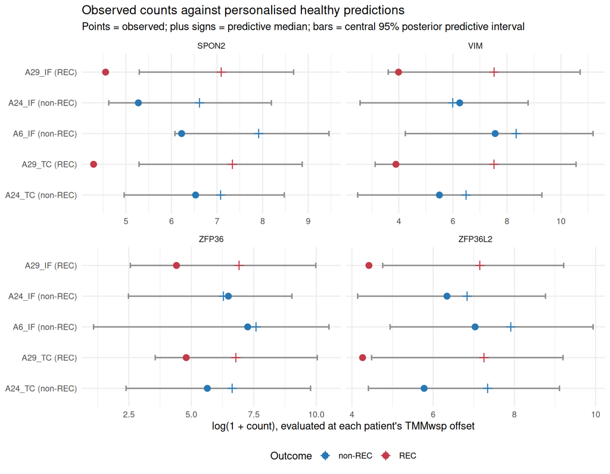

```r
plot_tests <- predictive_tests |>
  dplyr::mutate(
    sample_label = paste0(.data$sample_id, " (", .data$recurrence, ")"),
    sample_label = factor(
      .data$sample_label,
      levels = rev(unique(.data$sample_label))
    )
  )

ggplot2::ggplot(
  plot_tests,
  ggplot2::aes(
    y = .data$sample_label,
    colour = .data$recurrence
  )
) +
  ggplot2::geom_errorbar(
    ggplot2::aes(
      xmin = log1p(.data$healthy_predictive_lo),
      xmax = log1p(.data$healthy_predictive_hi)
    ),
    orientation = "y",
    width = 0.18,
    linewidth = 0.7,
    colour = "grey55"
  ) +
  ggplot2::geom_point(
    ggplot2::aes(x = log1p(.data$healthy_predictive_median)),
    shape = 3,
    size = 2.5,
    stroke = 0.8
  ) +
  ggplot2::geom_point(
    ggplot2::aes(x = log1p(.data$observed_count)),
    size = 2.8
  ) +
  ggplot2::facet_wrap(~ gene, scales = "free_x", ncol = 2) +
  ggplot2::scale_colour_manual(
    values = c(`non-REC` = "#2878B5", REC = "#C23B4A")
  ) +
  ggplot2::labs(
    title = "Observed counts against personalised healthy predictions",
    subtitle = "Points = observed; plus signs = predictive median; bars = central 95% posterior predictive interval",
    x = "log(1 + count), evaluated at each patient's TMMwsp offset",
    y = NULL,
    colour = "Outcome"
  ) +
  ggplot2::theme(legend.position = "bottom")
```

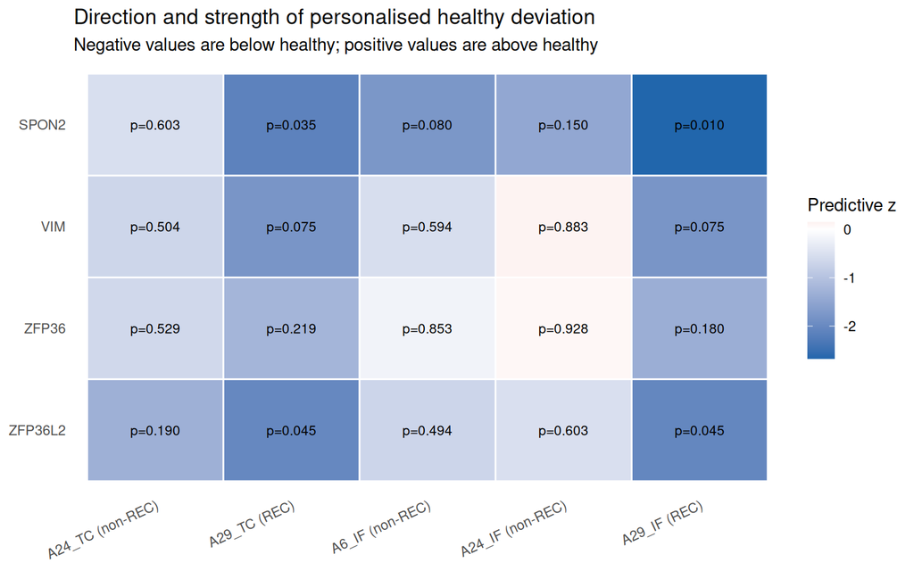

```r
ggplot2::ggplot(
  plot_tests,
  ggplot2::aes(
    x = .data$sample_label,
    y = forcats::fct_rev(factor(.data$gene)),
    fill = .data$predictive_z
  )
) +
  ggplot2::geom_tile(colour = "white", linewidth = 0.5) +
  ggplot2::geom_text(
    ggplot2::aes(label = sprintf("p=%.3f", .data$predictive_tail_p)),
    size = 3
  ) +
  ggplot2::scale_fill_gradient2(
    low = "#2166AC",
    mid = "white",
    high = "#B2182B",
    midpoint = 0,
    name = "Predictive z"
  ) +
  ggplot2::labs(
    title = "Direction and strength of personalised healthy deviation",
    subtitle = "Negative values are below healthy; positive values are above healthy",
    x = NULL,
    y = NULL
  ) +
  ggplot2::theme(
    panel.grid = ggplot2::element_blank(),
    axis.text.x = ggplot2::element_text(angle = 25, hjust = 1)
  )
```

## `posterior_linpred()`: patient and matched healthy density overlap

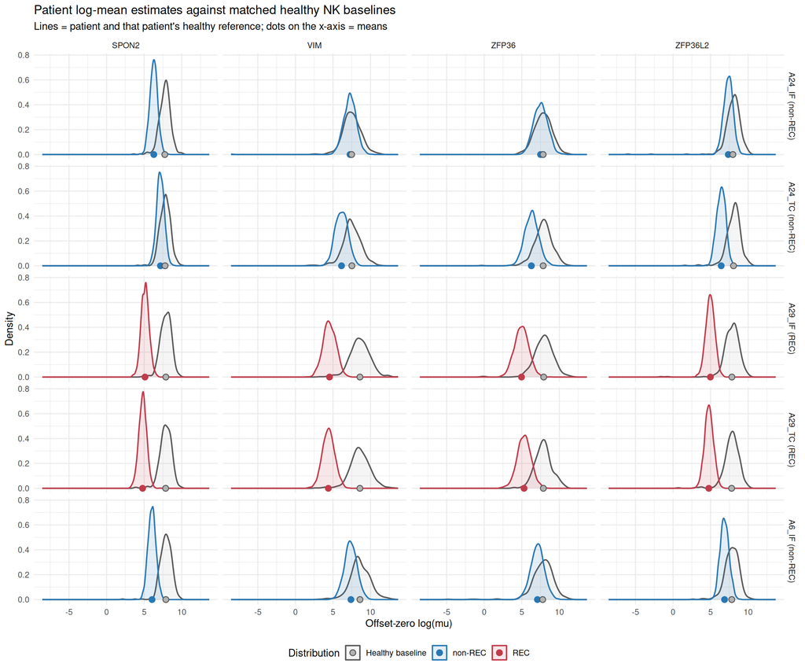

```r
set.seed(20250630)
patient_density <- linpred_tests |>
  dplyr::select(
    gene, sample_id, patient_id, compartment, recurrence,
    patient_log_mu, patient_log_mu_se
  ) |>
  tidyr::uncount(2000L, .id = "density_draw") |>
  dplyr::mutate(
    log_mu = stats::rnorm(
      dplyr::n(),
      mean = .data$patient_log_mu,
      sd = .data$patient_log_mu_se
    ),
    distribution = .data$recurrence
  )

healthy_density <- predictive_draws |>
  dplyr::select(gene, sample_id, healthy_linpred_log_mu) |>
  dplyr::left_join(
    linpred_tests |>
      dplyr::select(gene, sample_id, patient_id, compartment, recurrence),
    by = c("gene", "sample_id")
  ) |>
  dplyr::transmute(
    gene, sample_id, patient_id, compartment, recurrence,
    log_mu = .data$healthy_linpred_log_mu,
    distribution = "Healthy baseline"
  )

density_means <- dplyr::bind_rows(
  linpred_tests |>
    dplyr::transmute(
      gene, sample_id, patient_id, compartment, recurrence,
      mean_log_mu = .data$patient_log_mu,
      distribution = .data$recurrence
    ),
  linpred_tests |>
    dplyr::transmute(
      gene, sample_id, patient_id, compartment, recurrence,
      mean_log_mu = .data$healthy_log_mu_mean,
      distribution = "Healthy baseline"
    )
) |>
  dplyr::mutate(
    sample_label = paste0(.data$sample_id, " (", .data$recurrence, ")")
  )

density_data <- dplyr::bind_rows(patient_density, healthy_density) |>
  dplyr::mutate(
    sample_label = paste0(.data$sample_id, " (", .data$recurrence, ")")
  )

ggplot2::ggplot(
  density_data,
  ggplot2::aes(
    x = .data$log_mu,
    colour = .data$distribution,
    fill = .data$distribution
  )
) +
  ggplot2::geom_density(alpha = 0.12, linewidth = 0.7, adjust = 1.15) +
  ggplot2::geom_point(
    data = density_means,
    ggplot2::aes(
      x = .data$mean_log_mu,
      y = 0,
      colour = .data$distribution,
      fill = .data$distribution
    ),
    inherit.aes = FALSE,
    shape = 21,
    size = 2.5,
    stroke = 0.7
  ) +
  ggplot2::facet_grid(sample_label ~ gene) +
  ggplot2::scale_colour_manual(
    values = c(
      "Healthy baseline" = "grey35",
      "non-REC" = "#2878B5",
      REC = "#C23B4A"
    )
  ) +
  ggplot2::scale_fill_manual(
    values = c(
      "Healthy baseline" = "grey70",
      "non-REC" = "#2878B5",
      REC = "#C23B4A"
    )
  ) +
  ggplot2::labs(
    title = "Patient log-mean estimates against matched healthy NK baselines",
    subtitle = "Lines = patient and that patient's healthy reference; dots on the x-axis = means",
    x = "Offset-zero log(mu)",
    y = "Density",
    colour = "Distribution",
    fill = "Distribution"
  ) +
  ggplot2::theme(legend.position = "bottom")
```

Each panel contains exactly one HCC patient-compartment and the healthy `posterior_linpred()` distribution matched to that same patient. No baseline draws or patient estimates are pooled across individuals. Blue and red curves denote non-REC and REC only as an outcome annotation; coloured curves are normal approximations centred on NB-derived patient log means with their delta-method SEs.

## Outcome-free predictive patient scores

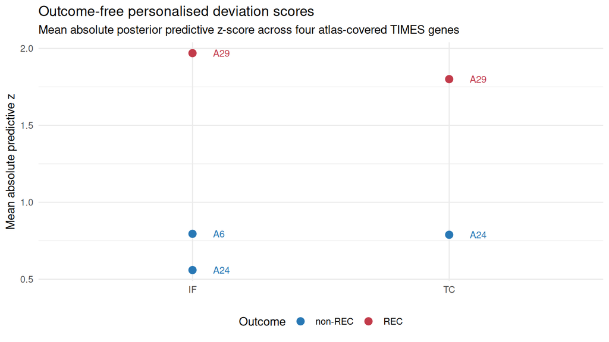

```r
ggplot2::ggplot(
  patient_scores,
  ggplot2::aes(
    x = .data$compartment,
    y = .data$mean_absolute_predictive_z,
    colour = .data$recurrence,
    label = .data$patient_id
  )
) +
  ggplot2::geom_point(size = 3) +
  ggplot2::geom_text(
    nudge_x = 0.08,
    hjust = 0,
    size = 3.2,
    show.legend = FALSE
  ) +
  ggplot2::scale_colour_manual(
    values = c(`non-REC` = "#2878B5", REC = "#C23B4A")
  ) +
  ggplot2::labs(
    title = "Outcome-free personalised deviation scores",
    subtitle = "Mean absolute posterior predictive z-score across four atlas-covered TIMES genes",
    x = NULL,
    y = "Mean absolute predictive z",
    colour = "Outcome"
  ) +
  ggplot2::theme(legend.position = "bottom")
```

# Interpretation

```r
n_tests <- nrow(predictive_tests)
n_outside <- sum(
  predictive_tests$direction != "consistent_with_personalised_healthy"
)
n_global_q <- sum(predictive_tests$q_value_global < 0.05)
n_below <- sum(
  predictive_tests$direction == "below_personalised_healthy"
)
n_above <- sum(
  predictive_tests$direction == "above_personalised_healthy"
)
n_below_epred <- sum(predictive_tests$log2fc_vs_healthy_epred < 0)

n_linpred_significant <- sum(linpred_tests$welch_style_p < 0.05)
n_linpred_global_q <- sum(linpred_tests$q_value_global < 0.05)
n_linpred_below <- sum(
  linpred_tests$direction == "below_personalised_healthy"
)
n_linpred_above <- sum(
  linpred_tests$direction == "above_personalised_healthy"
)
n_linpred_below_rec <- sum(
  linpred_tests$direction == "below_personalised_healthy" &
    linpred_tests$recurrence == "REC"
)
n_linpred_below_nonrec <- sum(
  linpred_tests$direction == "below_personalised_healthy" &
    linpred_tests$recurrence == "non-REC"
)

rec_scores <- patient_scores |>
  dplyr::filter(.data$recurrence == "REC") |>
  dplyr::pull(.data$mean_absolute_predictive_z)
nonrec_scores <- patient_scores |>
  dplyr::filter(.data$recurrence == "non-REC") |>
  dplyr::pull(.data$mean_absolute_predictive_z)

linpred_rec_scores <- linpred_patient_scores |>
  dplyr::filter(.data$recurrence == "REC") |>
  dplyr::pull(.data$mean_absolute_welch_z)
linpred_nonrec_scores <- linpred_patient_scores |>
  dplyr::filter(.data$recurrence == "non-REC") |>
  dplyr::pull(.data$mean_absolute_welch_z)

outside_predictive_interval <- predictive_tests |>
  dplyr::filter(
    .data$direction != "consistent_with_personalised_healthy"
  ) |>
  dplyr::select(
    gene, sample_id, recurrence, observed_count,
    healthy_predictive_lo, healthy_predictive_hi,
    predictive_tail_p, q_value_global, direction
  )
```

Across 20 gene-by-patient-compartment tests, 4 observations fall outside the central 95% personalised posterior predictive distribution: 4 below and 0 above healthy expectation. After global Benjamini-Hochberg adjustment, 0 remain below 0.05.

```r
outside_predictive_interval |>
  dplyr::mutate(
    dplyr::across(dplyr::where(is.numeric), ~round(.x, 4))
  )
```

```
# A tibble: 4 × 9
  gene    sample_id recurrence observed_count healthy_predictive_lo
  <chr>   <chr>     <chr>               <dbl>                 <dbl>
1 SPON2   A29_IF    REC                    94                 198.
2 ZFP36L2 A29_IF    REC                    82                 115.
3 SPON2   A29_TC    REC                    72                 197
4 ZFP36L2 A29_TC    REC                    70                  87.6
# ℹ 4 more variables: healthy_predictive_hi <dbl>, predictive_tail_p <dbl>,
#   q_value_global <dbl>, direction <chr>
```

All 20 observed counts are below their personalised healthy `posterior_epred` median. The stronger result is comparative rather than gene-wise significance: the REC patient A29 has mean absolute predictive z-scores of 1.969 in IF and 1.8 in TC. The available non-REC scores range from 0.56 to 0.795.

The `posterior_linpred` log-mean test reports 7 of 20 comparisons with an unadjusted normal-reference p-value below 0.05 (5 after global BH adjustment): 7 below and 0 above the personalised healthy mean. 6 below-healthy calls are in the REC patient, versus 1 in non-REC patients. A29’s mean absolute Welch-style z-score is 2.467 in IF and 2.547 in TC, versus 0.599 to 1.022 in non-REC samples. As in the predictive analysis, the outcome-free patient ordering is more stable than any single-gene threshold.

The patient score is a standardized predictive-deviation index, not a recurrence probability. Its recurrence discrimination is descriptive:

```r
performance |>
  dplyr::mutate(auc = round(.data$auc, 3))
```

```
# A tibble: 6 × 5
  analysis                      scope                    n_patients n_rec   auc
  <chr>                         <chr>                         <int> <int> <dbl>
1 posterior_predict             IF                                3     1     1
2 posterior_predict             TC                                2     1     1
3 posterior_predict             combined_available_IF_TC          3     1     1
4 posterior_linpred_welch_style IF                                3     1     1
5 posterior_linpred_welch_style TC                                2     1     1
6 posterior_linpred_welch_style combined_available_IF_TC          3     1     1
```

These results test whether posteriorHCA can create a patient-specific healthy counterfactual, not whether it has equal power to the original spatial TIMES model. The current evaluation has three patients, one REC patient, four atlas-covered genes, author-processed GeoMx values, and an assay platform absent from model training. Age, sex, tissue, offset, disease state, unknown fixed-effect uncertainty, dataset heterogeneity, and observation noise are handled explicitly; the remaining modality mismatch cannot be removed without healthy GeoMx liver NK training data or a fitted cross-platform calibration term.

The difference from the comprehensive cohort analysis is intentional. That analysis compares estimated latent log means and can provide sharper evidence about cohort displacement. Here, `posterior_linpred()` supplies the matched healthy log-mean distribution, while the patient log-mean SE is derived from its one-count NB sampling model. The primary personalised analysis instead asks whether one raw count is unusual for a new healthy observation, so `posterior_predict()` additionally represents zero-inflation and count generation. The log-mean test complements that calibrated predictive check; it must not be presented as a standard replicated-sample Welch t-test.

# Output files

```r
output_paths <- c(
  patient_metadata_csv = params$patient_metadata_csv,
  test_results_csv = params$test_results_csv,
  patient_scores_csv = params$patient_scores_csv,
  performance_csv = params$performance_csv,
  linpred_test_results_csv = params$linpred_test_results_csv,
  linpred_patient_scores_csv = params$linpred_patient_scores_csv,
  predictive_draws_rds = params$predictive_draws_rds
)

tibble::tibble(
  output = names(output_paths),
  path = unname(output_paths),
  exists = file.exists(output_paths)
)
```

```
# A tibble: 7 × 3
  output                     path                                         exists
  <chr>                      <chr>                                        <lgl>
1 patient_metadata_csv       /home/a1237163/lab/chen/posteriorHCA/dev/Ji… TRUE
2 test_results_csv           /home/a1237163/lab/chen/posteriorHCA/dev/Ji… TRUE
3 patient_scores_csv         /home/a1237163/lab/chen/posteriorHCA/dev/Ji… TRUE
4 performance_csv            /home/a1237163/lab/chen/posteriorHCA/dev/Ji… TRUE
5 linpred_test_results_csv   /home/a1237163/lab/chen/posteriorHCA/dev/Ji… TRUE
6 linpred_patient_scores_csv /home/a1237163/lab/chen/posteriorHCA/dev/Ji… TRUE
7 predictive_draws_rds       /home/a1237163/lab/chen/posteriorHCA/dev/Ji… TRUE
```